# Search for Milankovitch

## Introduction

In this notebook we hunt for Milankovitch cycles in the record of:

- Mix, A. C., J. Le, and N. J. Shackleton (1995a), Benthic foraminiferal stable isotope stratigraphy from Site 846: 0–1.8 Ma, Proc. Ocean Drill. Program Sci. Results, 138, 839–847.
- Shackleton, N. J. (1995), New data on the evolution of Pliocene climate variability, in Paleoclimate and Evolution, With Emphasis on Human Origins, edited by E. S. Vrba et al., pp. 242-248, Yale Univ. Press, New Haven, CT.

The data were aligned to the Benthic Stack of [Lisiecki & Raymo (2005)](https://agupubs.onlinelibrary.wiley.com/doi/abs/10.1029/2004PA001071) using the [HMM-Match](https://agupubs.onlinelibrary.wiley.com/doi/full/10.1002/2014PA002713) algorithm [(Khider et al, 2017)](https://agupubs.onlinelibrary.wiley.com/doi/abs/10.1002/2016PA003057).

First, load the data from `HMM_Alignment_8461.mat`.

```r
#install.packages("R.matlab")
library(R.matlab)
library(ggplot2)
library(ggthemes)
library(astrochron)
path <- "/Users/julieneg/Documents/Science/Research/GeoChronR/spectral/data"
pathname <- file.path(path, "HMM_Alignment_8461_v6.mat")
iodp846 <- readMat(pathname)
probstack <- read.table("/Users/julieneg/Documents/Science/Research/GeoChronR/spectral/data/Prob_stack.txt", header = FALSE)
```

```r
library(lipdR)
I = readLipd("ODP846.Lawrence.2006.lpd")
```

```
[1] "reading: ODP846.Lawrence.2006.lpd"
```

```r
d18O =  I$chronData[[1]]$model[[1]]$summaryTable[[1]]$d180$values
age.median <- I$chronData[[1]]$model[[1]]$summaryTable[[1]]$median$values
age.upper <- I$chronData[[1]]$model[[1]]$summaryTable[[1]]$upper95$values
age.lower <- I$chronData[[1]]$model[[1]]$summaryTable[[1]]$lower95$values
age.ens  <-  I$chronData[[1]]$model[[1]]$ensembleTable[[1]]$age$values
```

Let’s plot it

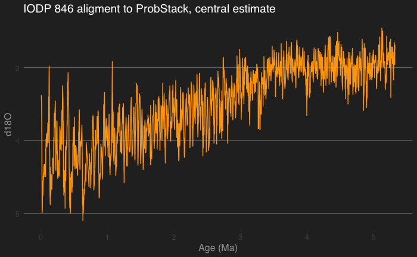

```r
df = data.frame(t = age.median, d18O=d18O, upper=age.upper, lower=age.lower, tens = age.ens)
ggplot(df) + geom_line(aes(x=t/1000,y=d18O),colour="orange") + ggtitle("IODP 846 aligment to ProbStack, central estimate") + ylab("d18O") + scale_x_continuous(breaks=seq(0,5)) + xlab("Age (Ma)") + scale_y_reverse() + theme_hc(base_size = 12, base_family = "sans", style = "darkunica", bgcolor = NULL)
```

Clearly there is a long-term trend here, paired with the transition from “41k world” to “100k world” somewhere around 0.8 Ma [Paillard, 2001]. To keep things simple and lower computational costs, let’s focus on the last 1 Ma. Now, a standard assumption of spectral analysis is that data are evenly spaced in time. In real-world paleo timeseries this is seldom the case. Let’s look at the distribution of time increments in this particular core, as contrained by this tuned age model:

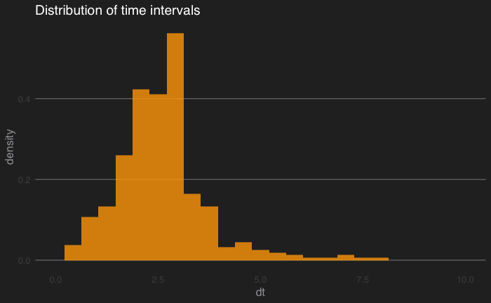

```r
dfs = dplyr::filter(df,t<=1000)
dt = diff(dfs$t)
ggplot() + xlim(c(0,10)) +
  geom_histogram(aes(x=dt,y = ..density..), bins = 25, ,alpha = 0.8, fill = "orange") + ggtitle("Distribution of time intervals") + theme_hc(base_size = 12, base_family = "sans", style = "darkunica", bgcolor = NULL)
```

We see that over the past Ma, the time increments (dt) are sharply peaked around 2.5 ka, but they range from 0 to about 7.5 ka. For now, let us assume that the time axis, uneven though it is, is well-known (no uncertainty).

## Time-certain spectral analysis

There are two ways to proceed: 1) use methods that explictly deal with unevenly-spaced data, or 2) interpolate to a regular grid and apply standard methods. For 1, we could use the *Lomb-Scargle periodogram* or the lesser-known *nuspectral* package. Let’s see what each method brings to the table.

### Lomb-Scargle periodogram

This is a very standard method implemented in many packages. For a review, see VanderPlas, J. T. (2018), Understanding the lomb–scargle periodogram, The Astrophysical Journal Supplement Series, 236(1), 16, doi:10.3847/1538-4365/aab766.

There are several ways to implement LS. GeoChronR does this via the lomb package:

```r
library(lomb)
spec.ls = lomb::lsp(dfs$d18O,times=dfs$t,ofac=1.1,plot = F)
```

```
ofac coerced to integer
```

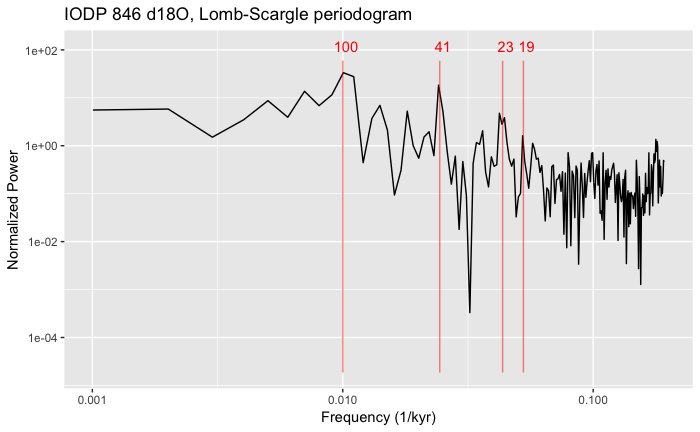

```r
# plot this
p.ls <- ggplot() + geom_line(aes(x=spec.ls$scanned,y=spec.ls$power)) + xlab("Frequency (1/kyr)") + ylab("Normalized Power") +scale_x_log10() +scale_y_log10() + ggtitle("IODP 846 d18O, Lomb-Scargle periodogram")
# define function to annotate the spectrum (assumes log10 scaling)
plotSpectraAnnotate = function (p, periods = c(19,23,41,100)){
  #get the x- and y-axis ranges actually used in the graph
  ggp <- ggplot_build(p)
  ylims <- ggp$layout$panel_params[[1]]$y.range # this will break with multiplots...
  for(per in periods){
    p <- p + annotate("segment", x = 1/per, xend = 1/per, y = 10**(ylims[1]-1), yend = 10**ylims[2],
    colour = "red", alpha = 0.5)
    p <- p +  annotate("text", x = 1.03*1/per, y = 2*10**ylims[2], label = format(per,digits=2, nsmall=0), colour = "red")
  }
return(p)
}
p.ls <- plotSpectraAnnotate(p.ls)
show(p.ls)
```

Where it is clearly seen that the data appear to contain periodic signals at the Milankotich frequencies (as well as quite a few others that appear almost as strong).

### Multi-taper Method

The Lomb-Scargle periodogram is a decent way to deal with unevenly-spaced timeseries, but it is still a periodogram, i.e. one of the worst estimators known to humankind. In particular, it is inconsistent: the variance of each estimate goes to infinity as the number of observations increases. A much better estimator is Thomson’s Multi-Taper Method [Thomson, 1982]. The downside is that it only handles evenly-spaced data. Small potatoes! The data are not that far from evenly-spaced, so let’s interpolate and see what we get. Conveniently, both the interpolation routine and MTM are available within the astrochron package:

```
----- APPLYING PIECEWISE-LINEAR INTERPOLATION TO STRATIGRAPHIC SERIES -----

 * Number of samples= 382
 * New number of samples= 398
```

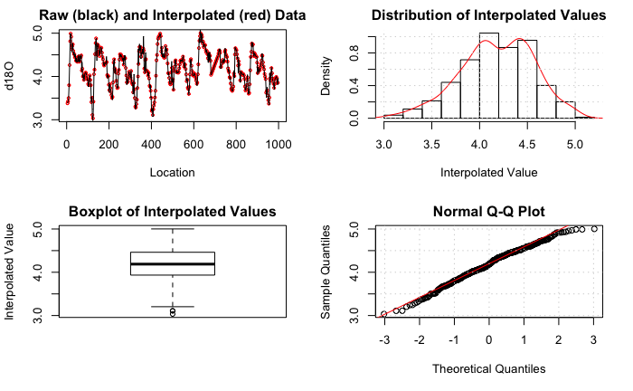

```r
library(astrochron)
dti = 2.5  # interpolation interval
dfe = linterp(dfs,dt=dti)
```

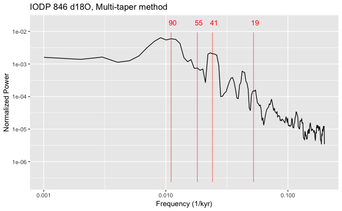

```r
spec.mtm <- astrochron::mtm(dfe,padfac=1,ar1=TRUE,genplot = F,output=1, verbose = F, detrend=T)
sig.freq <- astrochron::mtm(dfe,padfac=1,ar1=TRUE,genplot = F,output=2, verbose = F, detrend=T)
# plot this
p.mtm <- ggplot() + geom_line(aes(x=spec.mtm$Frequency,y=spec.mtm$Power)) + xlab("Frequency (1/kyr)") + ylab("Normalized Power") + scale_x_log10() +scale_y_log10() + ggtitle("IODP 846 d18O, Multi-taper method")
p.mtm <- plotSpectraAnnotate(p.mtm,periods = 1/sig.freq)
show(p.mtm)
```

We notice a few differences to the Lomb-Scargle periodogram. First, the high frequency part is much smoother, getting rid of a lot of high-frequency noise. This reveals a strong power law behavior from periods of 5 to 100 ky, which in this log-log plotting convention manifests as a linear decrease. *Astrochron* implements several tests to detect harmonic (sinusoidal) components. Like all tests, they are heavily dependent on a null hypothesis. The plain vanilla *astrochron::mtm()* assumes that we test against an AR(1) model. Using the option `output = 2` will export the frequencies identified as “significant” by this procedure. In this case, it identifies 41 and 19 ky (as it should), 90 ky (close enough to 100ky given the resolution), but surprisingly favors 55ky over the known 23ky precessional peak. Here it’s helpful to take a step back and contemplate our null hypothesis. Past work has shown that the continuum of climate variability is well described by power laws [Huybers & Curry, 2006] - this would be a far better null. Never fear! *Astrochron* has an app for that:

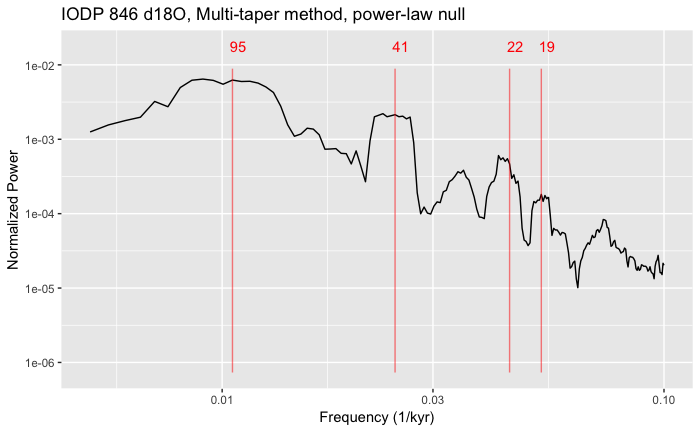

```r
fl = 0.005; fh = 0.1
spec.mtmPL <- astrochron::mtmPL(dfe,padfac=2,genplot = F,output=1, verbose = F, flow=fl, fhigh=fh)
sig.freqPL <- astrochron::mtmPL(dfe,padfac=2,genplot = F,output=2, verbose = F, flow=fl, fhigh=fh)
# plot this
p.mtmPL <- ggplot() + geom_line(aes(x=spec.mtmPL$Frequency,y=spec.mtmPL$Power)) + xlab("Frequency (1/kyr)") + ylab("Normalized Power") + scale_x_log10() +scale_y_log10() + ggtitle("IODP 846 d18O, Multi-taper method, power-law null")
p.mtmPL <- plotSpectraAnnotate(p.mtmPL,periods = 1/sig.freqPL)
show(p.mtmPL)
```

Sure enough, this gets rid of the 55 kyr cycle, and now we’ve got the split precessional peak, consistent with the astronomical forcing [Berger, 1978]. Here we defined `fhigh = 0.1` as the highest frequency at which to see cycles. Tweak it to see what happens when you use a higher one.